# Item Profiling and Forecasting - Time Series Class

Brad Pope

April, 2019

## Summary of the Dataset :

#### This is the sales history for a single UPC for a non-perishable product sold in a single retail location. The data was captured by a retailer when shoppers purchased the product. I chose this dataset as it is based on a relevant real world product to my company and I started working on the project before it was recommended we use data from the astsa package.

Start Year and Day: 2016, 268

Frequency (days in a year since daily): 365

## Exploration

#### Exploration of the dataset will take place with a trend, histogram and boxplots. Since there is only one variable there is no need to do scatterplot.

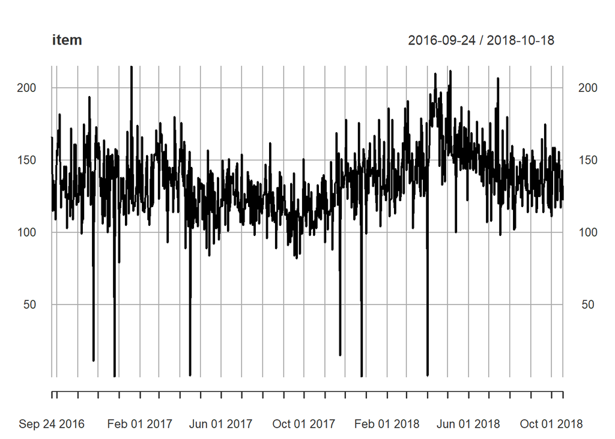

#### The plot over time doesn’t show a clear linear increase or decrease. There is variability that happens each week with some days that have zero sales (Major holidays or out of stocks).

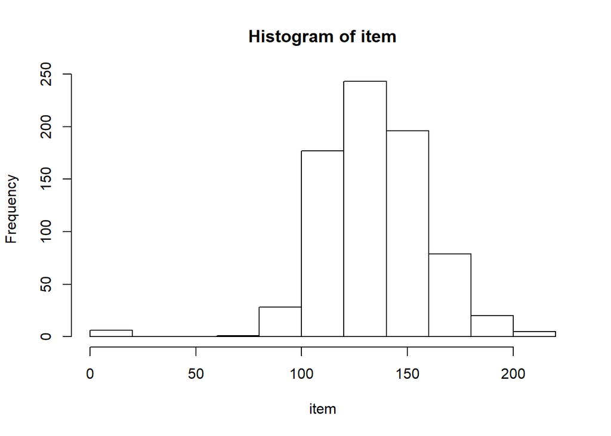

#### The histogram reveals a mostly normal distribution though we can see the zero and very low volume days on the left hand most bar. These are valid data points and should be left in.

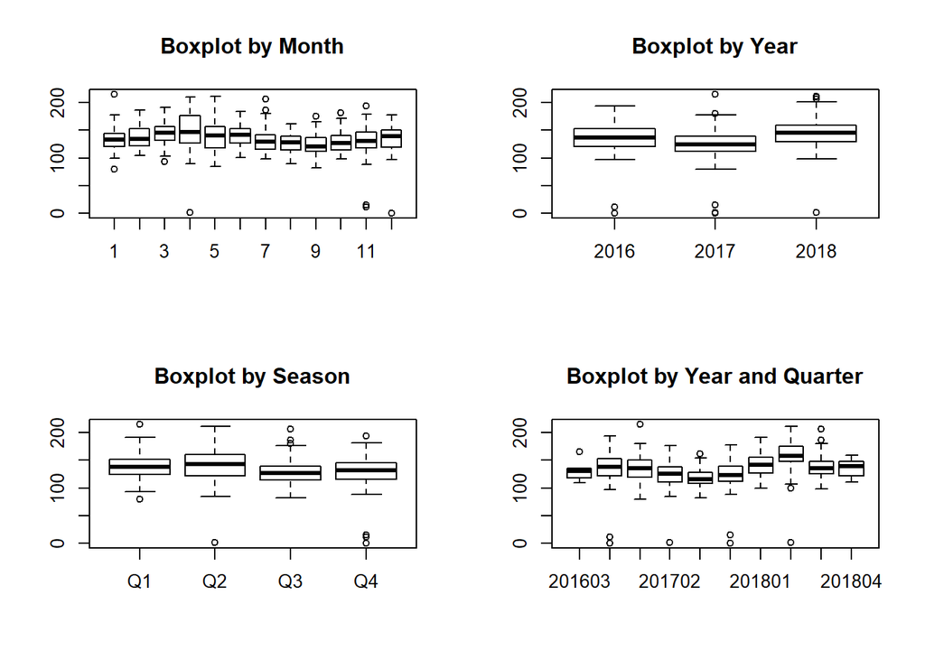

#### The set of boxplots show some of the potential differences by month, quarter and year. The inner quartile range of the boxes overlaps on many of the comparisons. While we do see more variation in some time periods with some YearQtr and month combinations selling more than others.

## Decomposition

#### Decomposition stage (plotting)

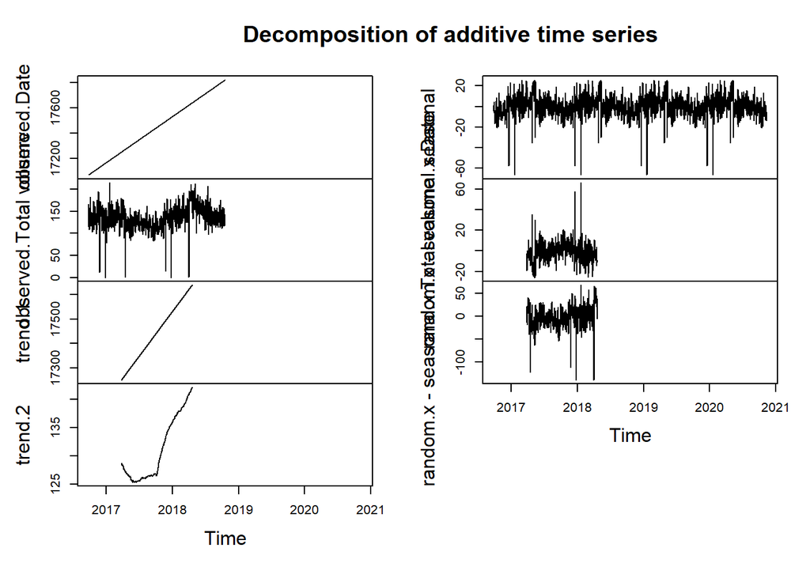

#### I chose additive because the seasonal and irregular components to not change despite the changes in the trend level.

#### The decomposition function was didn’t work quite the same as it did on the astsa package. I spent some time troubleshooting reviewing my dataset multiple times. There is a value for every day and, though there are days with zero sales, these are real occurrences so they should be included. Decompose may not be the best function for this data set. As such, the box plots above go a level deeper within each time period.

## Regression and Transformation

#### Building the model, evaluation and interpretation

#### The first step in the regression was to take the difference using the “diff” function to remove any trending and reexamine the ACF and PACF. Note: since the data didn’t scale up or down there was no need for the log (tested but didn’t yeild better results)

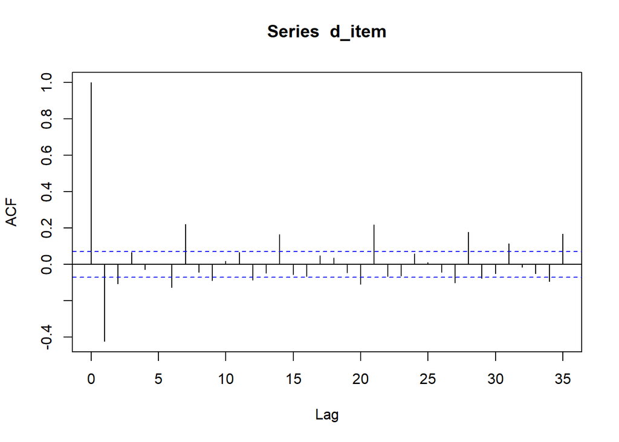

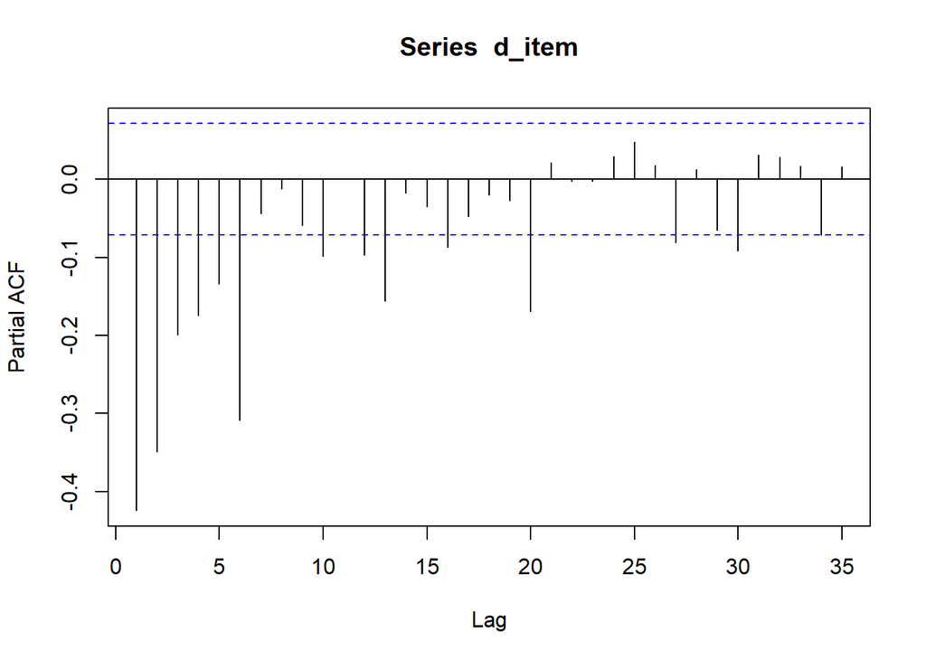

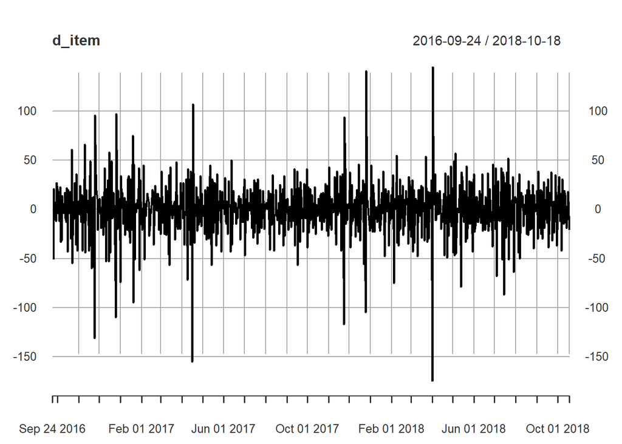

#### As we can see from the ACF graph both the ACF and PACF trail off which indicate a ARMA model where p = 1, and q = 1. Also, the time series of the differenced data exhibits some ARIMA behavior so “d”" was set equal to 1 as well. In testing multiple values 1 was the most effective.

#### In addition, when we look at the ACF we see that every seven days there is a spike indicating weekly seasonality. This makes sense because sales spikes are commonplace on Saturdays.

#### Next step is to remove the 7 day cyclical nature with diff(d_item,lag=7) and plot the ACF and PACF again.

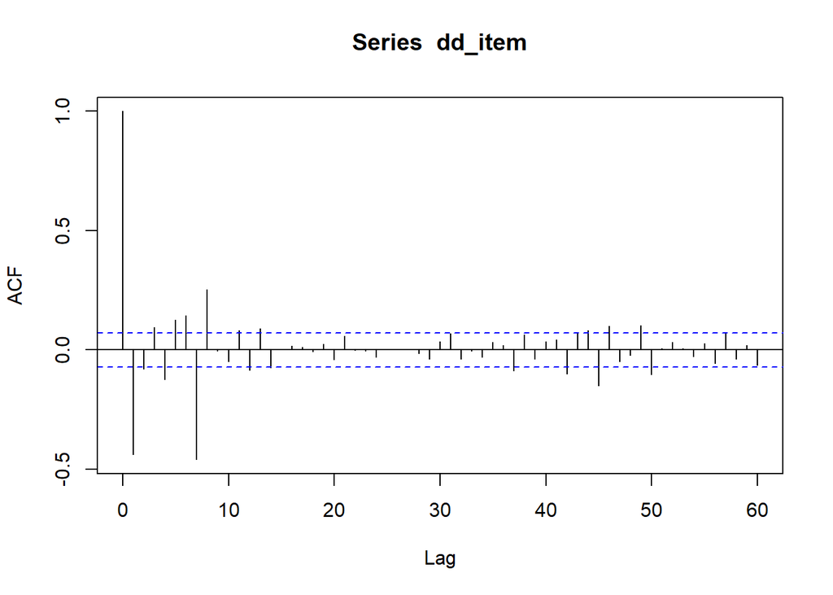

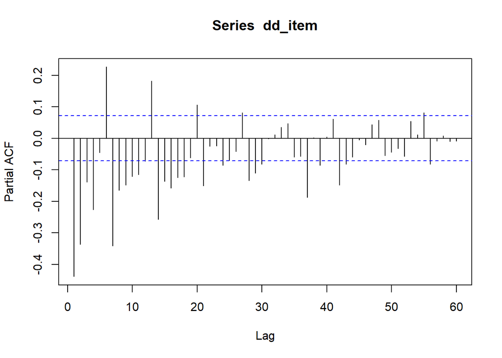

#### When the 7 day lag is controlled the ACF and PACF can be reviewed on each seasonal marker (each 7 days). When completed we see an ACF of 1 and PACF trailing off which represents a SMA(1) with a P = 0 and Q = 1. After experimentation D was set equal to 1 as well.

#### Based on those parameters here is the fit of the regression.

```
##      Estimate     SE  t.value p.value
## ar1    0.1429 0.0398   3.5917   4e-04
## ma1   -0.9305 0.0153 -61.0032   0e+00
## sma1  -1.0000 0.0134 -74.3990   0e+00
```

#### Since the P Values for ar1, ma1 and smal are less than .01 we can be 99% confident that they are significant and contributing to the model’s performance. There are additional model diagnostics below.

## Model Diagnostics

#### Next we’ll review more of Diagnostics to ensure a proper fit of the model. All of the diagnostics are printed below with a summary of the key pieces below.

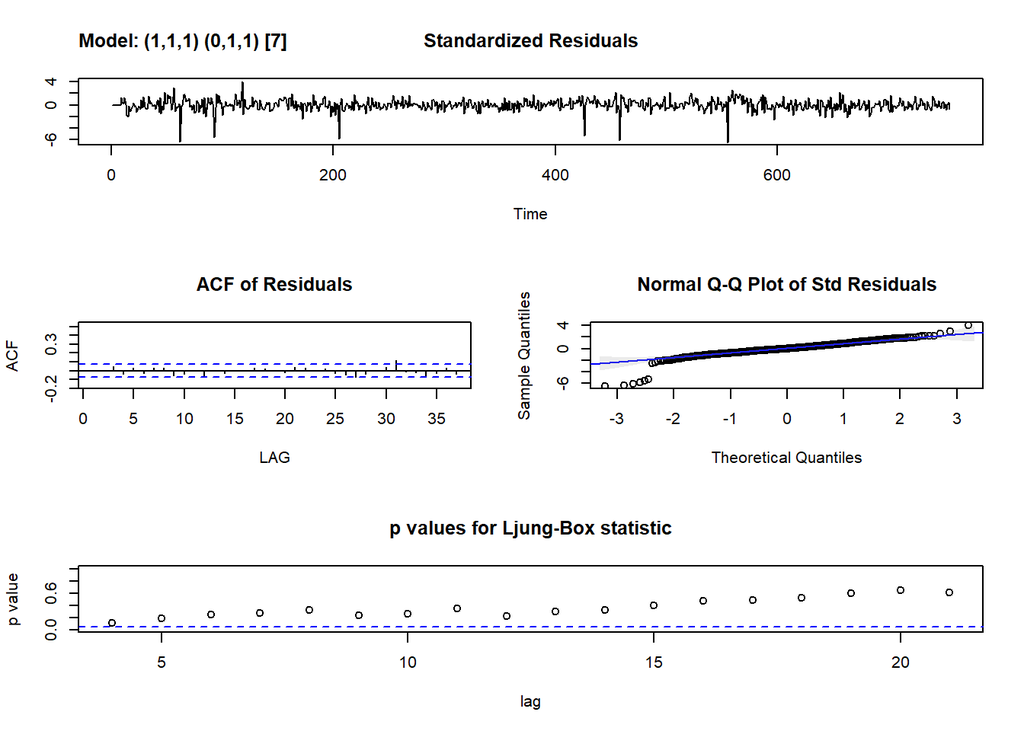

[output not shown]

```r
sarima(item,1,1,1,0,1,1,7)
```

#### First review the Graphs of the Residual Analysis

##### Q-statistic P Values - With another wideness assessment the points are above the line so an assumption can be made that the noise is white.

#### The AIC and BIC values are also relatively small. To ensure the best fit over a dozen other models were run but all had higher AIC and BIC values indicating that the model derived from the ACF and PACF was sound.

## Model Forecast

#### Since the model represents the underlying dataset well, we can then use sarima.for against the same model to forecast sales.

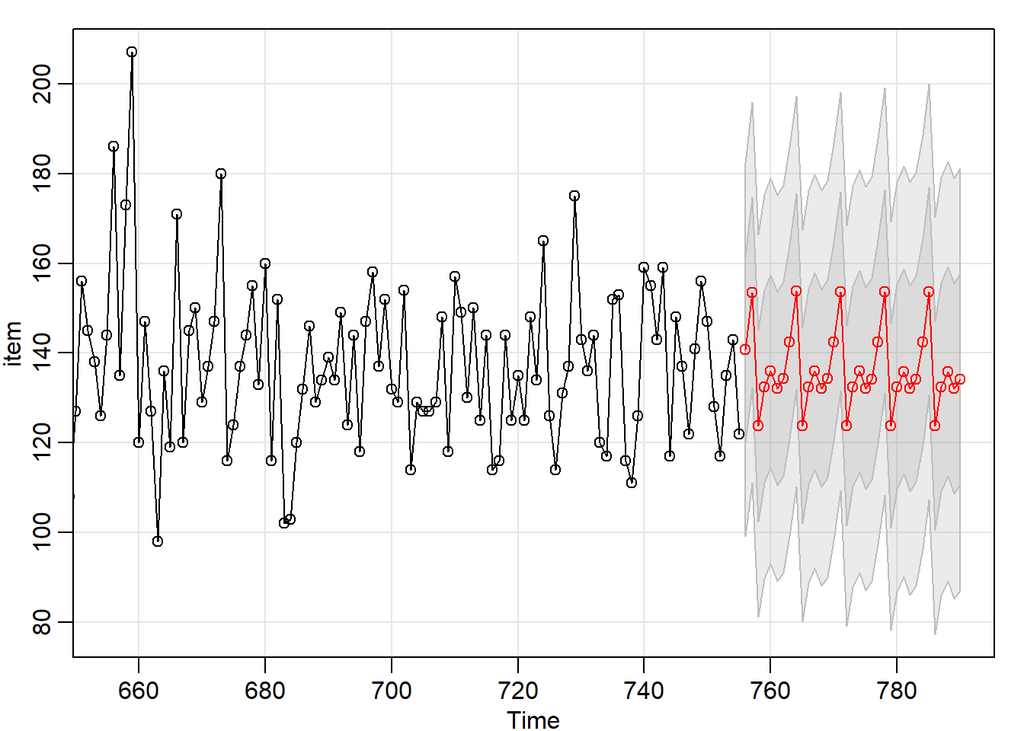

```
## $pred
## Time Series:
## Start = 756
## End = 790
## Frequency = 1
##  [1] 140.7649 153.4978 123.7884 132.5138 135.9442 132.1395 134.2432
##  [8] 142.5033 153.7349 123.8109 132.5057 135.9317 132.1264 134.2300
## [15] 142.4901 153.7216 123.7977 132.4924 135.9184 132.1131 134.2167
## [22] 142.4768 153.7084 123.7845 132.4792 135.9052 132.0999 134.2035
## [29] 142.4636 153.6952 123.7712 132.4660 135.8920 132.0867 134.1903
##
## $se
## Time Series:
## Start = 756
## End = 790
## Frequency = 1
##  [1] 20.75239 21.21503 21.31592 21.38661 21.45326 21.51917 21.58481
##  [8] 21.66608 21.73431 21.80075 21.86674 21.93251 21.99808 22.06346
## [15] 22.14430 22.21238 22.27856 22.34431 22.40984 22.47517 22.54032
## [22] 22.62076 22.68870 22.75464 22.82016 22.88545 22.95056 23.01550
## [29] 23.09555 23.16338 23.22909 23.29439 23.35947 23.42436 23.48910
```

#### This concludes the summary, exploratory, decomposition, regression, modeling, diagnostics and forecasting of the product information for the final project.

## Thanks for instructing the Time Series class!